# Association Analysis

Varun Manoj

20/05/2021

## Introduction

> [**Association Analysis**](https://www.jmp.com/support/help/en/15.2/index.shtml#page/jmp/association-analysis.shtml) enables you to identify items that have an affinity for each other. It is frequently used to analyze transactional data (also called market baskets) to identify items that often appear together in transactions. For example, grocery stores and online merchants use association analysis to strategically organize and recommend products that tend to be purchased together.

## Data Preprocessing

This blog’s dataset is actually an extension from last month’s dataset. I wanted to test myself with a larger dataset but couldn’t seem to find an appropriate one until I stumbled upon [retail data](https://archive.ics.uci.edu/ml/datasets/Online+Retail+II) of the two years prior to the previously used dataset. In case you missed the last blog post, here’s a [recap](https://varunmanoj.blog/2021/01/27/clustering-from-sales-trancation-data/) of the dataset from the last blog post.

The goal of data preprocessing often differs with the choice of analytical model. We need a very particular format of data for association analysis: two columns, one with an invoice or transaction ID, and the other with a column of items purchased by description. Keeping that goal in mind, we can manipulate our dataset accordingly to transform it to the desired format. We must note that this format is inconsistent with [tidy data principles](https://cran.r-project.org/web/packages/tidyr/vignettes/tidy-data.html), however it’s required for this type of analysis. We begin the analysis by importing the two different transaction record files and combining them into one data frame. We need to be careful about naming conventions, as we can already see some inconsistency between the two sets of transaction data. We can fix the problem by using the `rename()` function, and rename the columns ‘Price’, ‘Invoice’ and ‘Customer ID’ to ‘UnitPrice’, ‘InvoiceNo’ and ‘CustomerID’ respectively.

```r
#Read both transaction records
#If not initialised, set your working directory by using setwd()
retail_old <- read_excel("online_retail_II.xlsx")
retail_new <- read_excel("Online Retail.xlsx")

#Use standardized naming conventions
retail_old <- retail_old %>%
  rename(c("Invoice" = "InvoiceNo", "Price" = "UnitPrice" , `Customer ID` = "CustomerID"))

#Combine rows, this is a base R function with the tidyverse version being rbind()
retail <- bind_rows(retail_new, retail_old)

#Find summary statistics
summary(retail)
```

```
##   InvoiceNo          StockCode         Description           Quantity
##  Length:1067370     Length:1067370     Length:1067370     Min.   :-80995.00
##  Class :character   Class :character   Class :character   1st Qu.:     1.00
##  Mode  :character   Mode  :character   Mode  :character   Median :     3.00
##                                                           Mean   :     9.94
##                                                           3rd Qu.:    10.00
##                                                           Max.   : 80995.00
##
##   InvoiceDate                    UnitPrice           CustomerID
##  Min.   :2009-12-01 07:45:00   Min.   :-53594.36   Min.   :12346
##  1st Qu.:2010-07-09 09:46:00   1st Qu.:     1.25   1st Qu.:13975
##  Median :2010-12-07 15:28:00   Median :     2.10   Median :15255
##  Mean   :2011-01-02 21:13:27   Mean   :     4.65   Mean   :15325
##  3rd Qu.:2011-07-22 10:23:00   3rd Qu.:     4.15   3rd Qu.:16797
##  Max.   :2011-12-09 12:50:00   Max.   : 38970.00   Max.   :18287
##                                                    NA's   :243007
##    Country
##  Length:1067370
##  Class :character
##  Mode  :character
##
##
##
##
```

The combined dataset 1,067,370 observations but the data’s far from clean. We can see a couple of problems from the results of the `summary()` function: over 240,000 records have NA’s in the CustomerID variable, at least 1 record has a negative UnitPrice and at least 1 record has a negative Quantity. We don’t need to be worried about the CustomerID variable for association analysis, but we do need to ensure our dataset has only positive values for UnitPrice and Quantity. We can filter for our requirements using the `filter()` function and confirm we have a complete datatset by checking the `is.na()` function:

```r
#Include only positive values
retail_clean <- retail %>%
  filter(Quantity > 0 & UnitPrice > 0)

#Check for presence of NAs
retail_clean %>%
  filter(is.na(Description))
```

```
## # A tibble: 0 x 8
## # … with 8 variables: InvoiceNo <chr>, StockCode <chr>, Description <chr>,
## #   Quantity <dbl>, InvoiceDate <dttm>, UnitPrice <dbl>, CustomerID <dbl>,
## #   Country <chr>
```

This data frame seems to have complete data for all the variables that we require. Next, let’s explore the StockCode column to check if there are any problems. We can see that there are three main types of StockCode variables: numeric, alpha-numeric and alphabets. This is a perfect opportunity to use some REGEX to differentiate observations and determine whether or not to include certain observations. We can begin by using REGEX to filter out all non-numeric StockCodes by using the `grepl()` function to specify our regular expression.

```r
#Data's clean but not clean enough, there are still StockCodes such as M, Amazonfee etc. that need to be removed
#Let's see all the non-numeric StockCodes
misc_StockCode <- retail_clean %>%
  filter(!grepl('^[0-9]', StockCode))
```

There are only 4,793 observations with these ‘miscellaneous’ StockCodes, however they can still affect our association analysis and must examine these variables. Upon inspection of these observations, we can see that there are StockCodes that resemble ‘Postage’, ‘Manual’ and ‘Dotcom Postage’, all of which aren’t items that are sold by the retailer. On the contrary, there are StockCodes such as ‘C2’ and ‘gift’ which resemble ‘Carriage’ and ‘Gift card’ respectively and are items that the retailer sells. We need to use our own judgement here to determine whether to include certain observations, and I feel a good rule of thumb is keep items that have multiple observations with the same StockCode, Description and UnitPrice, and discard the rest. This shows that an item is consistently priced for the same description, hence must be an item sold by the retailer. We can modify the previous REGEX to include non-numerics, along with StockCodes that begin with ‘DCGS’, ‘gift’, ‘C2’ and ‘SP’. We’ve display some of these ‘good’ and ‘bad’ StockCodes in a tabular format below. We can subsequently update the retail_clean data frame to exclude those observations.

**Differentiating StockCodes**

Segregating StockCodes into Good and Bad

| StockCode | Description |
| --- | --- |
| Good StockCodes |  |
| C2 | CARRIAGE |
| DCGS0076 | SUNJAR LED NIGHT NIGHT LIGHT |
| DCGS0003 | BOXED GLASS ASHTRAY |
| gift_0001_40 | Dotcomgiftshop Gift Voucher £40.00 |
| DCGS0070 | CAMOUFLAGE DOG COLLAR |
| gift_0001_50 | Dotcomgiftshop Gift Voucher £50.00 |
| gift_0001_30 | Dotcomgiftshop Gift Voucher £30.00 |
| gift_0001_20 | Dotcomgiftshop Gift Voucher £20.00 |
| DCGS0069 | OOH LA LA DOGS COLLAR |
| DCGSSBOY | BOYS PARTY BAG |
| DCGSSGIRL | GIRLS PARTY BAG |
| gift_0001_10 | Dotcomgiftshop Gift Voucher £10.00 |
| Bad StockCodes |  |
| POST | POSTAGE |
| DOT | DOTCOM POSTAGE |
| M | Manual |
| BANK CHARGES | Bank Charges |
| AMAZONFEE | AMAZON FEE |
| m | Manual |
| S | SAMPLES |
| PADS | PADS TO MATCH ALL CUSHIONS |

## Data Integrity

The inconsistent naming conventions that we observed in the previous section is a red flag that other elements of the dataset might need further inspection. Upon taking a glance at the observations we can see that there’s potentially naming inconsistencies in the database. One StockCode could have multiple descriptions and one Description could have multiple StockCodes. This is a sign of poor database design and can lead to serious problems if unaddressed. We can explore some of the duplicate StockCode and Description combinations and subsequently make a decision on how to deal with those.

**Duplicate Descriptions**

Same *Descriptions* with Different *StockCodes*

| StockCode | Description | Number of Duplicates |
| --- | --- | --- |
| 82613B | METAL SIGN,CUPCAKE SINGLE HOOK | 6 |
| 82613C | METAL SIGN,CUPCAKE SINGLE HOOK | 6 |
| 82613A | METAL SIGN,CUPCAKE SINGLE HOOK | 6 |
| 82613b | METAL SIGN,CUPCAKE SINGLE HOOK | 6 |
| 82613c | METAL SIGN,CUPCAKE SINGLE HOOK | 6 |
| 82613a | METAL SIGN,CUPCAKE SINGLE HOOK | 6 |
| 72127 | COLUMBIAN CANDLE ROUND | 4 |
| 72130 | COLUMBIAN CANDLE ROUND | 4 |
| 72128 | COLUMBIAN CANDLE ROUND | 4 |
| 72129 | COLUMBIAN CANDLE ROUND | 4 |
| 84509B | SET OF 4 FAIRY CAKE PLACEMATS | 4 |
| 84509G | SET OF 4 FAIRY CAKE PLACEMATS | 4 |
| 84509b | SET OF 4 FAIRY CAKE PLACEMATS | 4 |
| 84509g | SET OF 4 FAIRY CAKE PLACEMATS | 4 |
| 10133 | COLOURING PENCILS BROWN TUBE | 3 |
| 10135 | COLOURING PENCILS BROWN TUBE | 3 |
| 10134 | COLOURING PENCILS BROWN TUBE | 3 |
| 20884 | MODERN CHRISTMAS TREE CANDLE | 3 |
| 20881 | MODERN CHRISTMAS TREE CANDLE | 3 |
| 20882 | MODERN CHRISTMAS TREE CANDLE | 3 |

**Duplicate StockCodes**

Same *StockCodes* with Different *Descriptions*

| StockCode | Description | Number of Duplicates |
| --- | --- | --- |
| 20685 | DOORMAT RED RETROSPOT | 4 |
| 20685 | RED SPOTTY COIR DOORMAT | 4 |
| 20685 | DOOR MAT RED SPOT | 4 |
| 20685 | DOORMAT RED SPOT | 4 |
| 22344 | PARTY PIZZA DISH PINK POLKADOT | 4 |
| 22344 | PARTY PIZZA DISH PINK+WHITE SPOT | 4 |
| 22344 | PARTY PIZZA DISH PINK WHITE SPOT | 4 |
| 22344 | PARTY PIZZA DISH PINK RETROSPOT | 4 |
| 22345 | PARTY PIZZA DISH BLUE POLKADOT | 4 |
| 22345 | PARTY PIZZA DISH BLUE+WHITE SPOT | 4 |
| 22345 | PARTY PIZZA DISH BLUE WHITE SPOT | 4 |
| 22345 | PARTY PIZZA DISH BLUE RETROSPOT | 4 |
| 22346 | PARTY PIZZA DISH GREEN POLKADOT | 4 |
| 22346 | PARTY PIZZA DISH GREEN+WHITE SPOT | 4 |
| 22346 | PARTY PIZZA DISH GREEN WHITE SPOT | 4 |
| 22346 | PARTY PIZZA DISH GREEN RETROSPOT | 4 |
| 22384 | LUNCH BAG PINK POLKADOT | 4 |
| 22384 | LUNCHBAG PINK RETROSPOT | 4 |
| 22384 | LUNCH BAG PINK RETROSPOT | 4 |
| 22384 | LUNCH BAG PINK POLKADOTS | 4 |

We can see the records of duplicates of both StockCode and Description. There are 1,256 observations with the same StockCode and but different Description combinations–600 distinct StockCodes but 1,256 unique Descriptions for these StockCodes. Meanwhile, there are only 82 observations with the same Description but different StockCode combination, with 38 unique Descriptions spanning across 78 distinct StockCodes. Now that we have all the StockCodes for the items that are duplicates, we can enter these StockCodes into our retail_clean data frame to see how many of our transactions are duplicates. Quite surprisingly, over 240,000 transactions include those of duplicated items. This means that the same item might have two (or more) different StockCodes and all different StockCode-Description combinations are credited for the sale. This can be extremely misleading for the analyst as we are unsure which is truly the ‘correct’ StockCode-Description combination. Moreover, this can be troublesome for our analysis as items may have a strong lift or support value but because they have multiple descriptions, we might not be able to uncover their true associations. On the flip side, if we choose to exclude these observations then we might be forgoing information on really popular or profitable products for the retailer. For this reason, I chose to include the duplicated items but with much hesitation.

## Exploratory Data Analysis

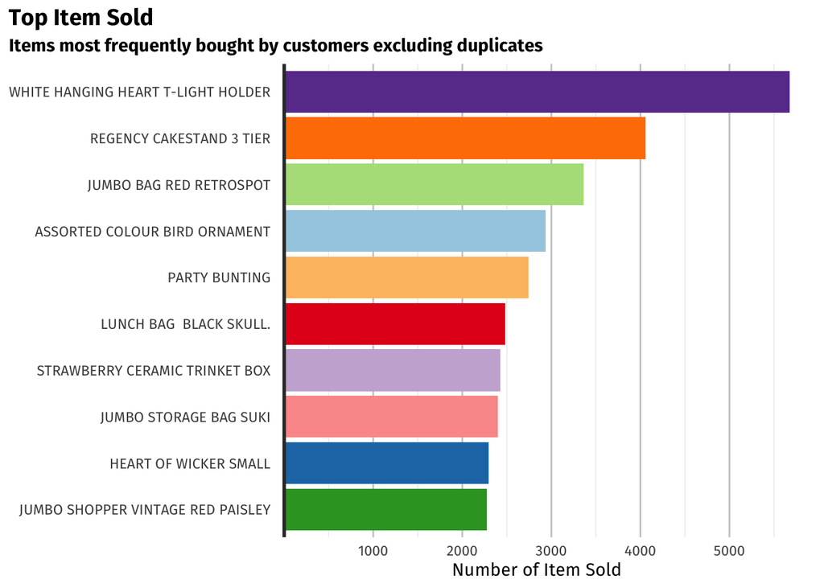

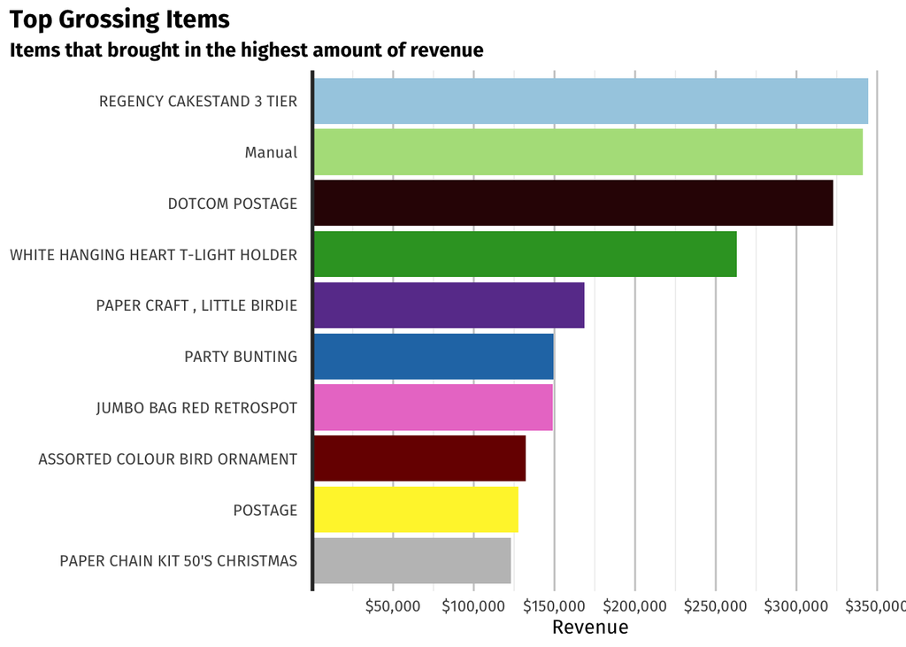

| Description | Total Item Sold | Total Transactions | Difference |
| --- | --- | --- | --- |
| WORLD WAR 2 GLIDERS ASSTD DESIGNS | 110138 | 1043 | 109095 |
| WHITE HANGING HEART T-LIGHT HOLDER | 96086 | 5677 | 90409 |
| ASSORTED COLOUR BIRD ORNAMENT | 81809 | 2938 | 78871 |
| PAPER CRAFT , LITTLE BIRDIE | 80995 | 1 | 80994 |
| JUMBO BAG RED RETROSPOT | 78860 | 3366 | 75494 |
| MEDIUM CERAMIC TOP STORAGE JAR | 78033 | 250 | 77783 |
| BROCADE RING PURSE | 71430 | 476 | 70954 |
| PACK OF 60 PINK PAISLEY CAKE CASES | 56794 | 2081 | 54713 |
| 60 TEATIME FAIRY CAKE CASES | 54716 | 2257 | 52459 |
| SMALL POPCORN HOLDER | 49948 | 1504 | 48444 |
| PACK OF 72 RETROSPOT CAKE CASES | 49805 | 1834 | 47971 |
| PACK OF 72 RETRO SPOT CAKE CASES | 46755 | 1456 | 45299 |
| MINI PAINT SET VINTAGE | 44405 | 731 | 43674 |
| ASSORTED COLOURS SILK FAN | 44365 | 1003 | 43362 |
| COLOUR GLASS T-LIGHT HOLDER HANGING | 40839 | 1302 | 39537 |
| VICTORIAN GLASS HANGING T-LIGHT | 40748 | 1889 | 38859 |
| PACK OF 72 SKULL CAKE CASES | 40733 | 1548 | 39185 |
| PACK OF 12 LONDON TISSUES | 40163 | 884 | 39279 |
| GIRLS ALPHABET IRON ON PATCHES | 38574 | 314 | 38260 |
| RED HARMONICA IN BOX | 38191 | 1073 | 37118 |

Now that we’ve found some meaningful relationships in our dataset, we can proceed to the data manipulation stage to get the data ready for association analysis.

## Data Manupilation

Now that we have a better understanding of our dataset and have explored its various dimensions, we can begin the data manipulation process to fit the dataset to an association rules model. Our goal is to produce a dataset where each row is an observation of a unique transaction, depicted by InvoiceNo. The ideal dataset will only have two columns–InvoiceNo and a newly created ‘items’ column, which is a string concatenation of all items purchased in that transaction. However, string concatenations are generally separated with a comma, but certain product names in the Description column already have commas. Let’s take a look at some of the product descriptions that have a comma and see if we can possibly replace it.

```r
retail_clean %>%
  filter(grepl(",", Description)) %>%
  head(n = 20) %>%
  gt() %>%
  cols_align(align = "center",
             columns = "Quantity") %>%
  tab_options(table.font.size = pct(85))
```

| InvoiceNo | StockCode | Description | Quantity | InvoiceDate | UnitPrice | CustomerID | Country |
| --- | --- | --- | --- | --- | --- | --- | --- |
| 536381 | 82567 | AIRLINE LOUNGE,METAL SIGN | 2 | 2010-12-01 09:41:00 | 2.10 | 15311 | United Kingdom |
| 536394 | 21506 | FANCY FONT BIRTHDAY CARD, | 24 | 2010-12-01 10:39:00 | 0.42 | 13408 | United Kingdom |
| 536520 | 22760 | TRAY, BREAKFAST IN BED | 1 | 2010-12-01 12:43:00 | 12.75 | 14729 | United Kingdom |
| 536520 | 21111 | SWISS ROLL TOWEL, CHOCOLATE SPOTS | 1 | 2010-12-01 12:43:00 | 2.95 | 14729 | United Kingdom |
| 536524 | 21111 | SWISS ROLL TOWEL, CHOCOLATE SPOTS | 6 | 2010-12-01 12:51:00 | 2.95 | 17572 | United Kingdom |
| 536531 | 22819 | BIRTHDAY CARD, RETRO SPOT | 24 | 2010-12-01 13:23:00 | 0.42 | 15485 | United Kingdom |
| 536531 | 21506 | FANCY FONT BIRTHDAY CARD, | 24 | 2010-12-01 13:23:00 | 0.42 | 15485 | United Kingdom |
| 536532 | 21506 | FANCY FONT BIRTHDAY CARD, | 12 | 2010-12-01 13:24:00 | 0.42 | 12433 | Norway |
| 536544 | 22760 | TRAY, BREAKFAST IN BED | 1 | 2010-12-01 14:32:00 | 25.49 | NA | United Kingdom |
| 536544 | 35818P | ACRYLIC JEWEL ICICLE, PINK | 1 | 2010-12-01 14:32:00 | 3.36 | NA | United Kingdom |
| 536544 | 79030D | TUMBLER, BAROQUE | 1 | 2010-12-01 14:32:00 | 12.72 | NA | United Kingdom |
| 536544 | 79030G | TUMBLER, NEW ENGLAND | 1 | 2010-12-01 14:32:00 | 12.72 | NA | United Kingdom |
| 536544 | 82613B | METAL SIGN,CUPCAKE SINGLE HOOK | 1 | 2010-12-01 14:32:00 | 2.51 | NA | United Kingdom |
| 536544 | 82613C | METAL SIGN,CUPCAKE SINGLE HOOK | 1 | 2010-12-01 14:32:00 | 2.51 | NA | United Kingdom |
| 536544 | 21216 | SET 3 RETROSPOT TEA,COFFEE,SUGAR | 1 | 2010-12-01 14:32:00 | 11.02 | NA | United Kingdom |
| 536544 | 21507 | ELEPHANT, BIRTHDAY CARD, | 1 | 2010-12-01 14:32:00 | 0.85 | NA | United Kingdom |
| 536559 | 51014C | FEATHER PEN,COAL BLACK | 24 | 2010-12-01 14:54:00 | 0.85 | 17873 | United Kingdom |
| 536559 | 51014L | FEATHER PEN,LIGHT PINK | 12 | 2010-12-01 14:54:00 | 0.85 | 17873 | United Kingdom |
| 536559 | 51014L | FEATHER PEN,LIGHT PINK | 12 | 2010-12-01 14:54:00 | 0.85 | 17873 | United Kingdom |
| 536559 | 51014C | FEATHER PEN,COAL BLACK | 12 | 2010-12-01 14:54:00 | 0.85 | 17873 | United Kingdom |

As we can see above, the use of commas in product names is very inconsistent as sometimes there’s whitespace between characters while sometimes there isn’t. Notably, we can see if we drop the comma it doesn’t change our comprehension ability of the product. We can go ahead and drop the comma by applying the `gsub()` function in the `apply()` function. Next, we can use the `ddply()` function to create a dataframe of only one column of the string concatenation of all products. We can then write this data frame as a CSV, and read it back in using the `read.transactions()` function from the [arules package](https://cran.r-project.org/web/packages/arules/arules.pdf). The arules package provides several computation methods required to conduct our market basket analysis.

```r
##A comma throws everything off but we can still keep other punctuation
no_comma <- apply(retail_clean, 2, FUN = function(y) gsub(',','', y))

#Before this step ensure you don't want to put a unique() function to get only 1 item per itemset
transactionData <- ddply(data.frame(no_comma), "InvoiceNo",
                         function(x) paste(x$Description,
                                            collapse = ","))
```

## Market Basket Analysis

Before we begin our analysis, let’s go through the three main concepts of market basket analysis: support, confidence and lift.

- Support: The ‘popularity’ of the rule. Support is calculated by finding the probability of both item A and item B being observed together. It’s simply the percentage of the total number of transactions that qualify for the rule.
- Confidence: The ‘strength’ of the rule. The probability of observing item B when item A is already observed. This is basically the number of transactions that satisfy the rule (both item A and B) divided by the number of transactions that satisfy the left-hand side of the rule (only item A).
- Lift: The ‘significance’ of the rule. This value is calculated by finding the ratio of the probability of items A and B occurring together divided by the two individual probabilities for item A and item B. Hence, a lift value greater than 1 means that the rule observed can be attributed to more than just random chance. The goal of our analysis is to find itemsets with large lift values above a minimum threshold of support and confidence values. This used to be a traditionally computationally intensive method, but has become a lot quicker with the introduction of new algorithms. There are different algorithms used to help greatly increase the computation speed, such as apriori, frequent-purchase (FP) growth, SETM algorithms. For the purpose of this analysis, I’ll use the popular apriori algorithm.

The ‘magic’ behind the apriori algorithm lies in the anti-monotone property of support values. This basically states that if an itemset {A, B} is infrequent, then all of its supersets must be infrequent too. Hence, instead of calculating the support, confidence and lift value of every combination of itemset, we can prune out infrequent itemsets and focus the computational power on the frequent itemsets. This can be observed in the image below where there are two different hypothetical situations displayed. The image with the red outline shows us the amount of potential combinations of 5 itemsets that are pruned away if it’s discovered that itemset {A} and itemset {B} individually have low support values. Similarly, the image with the purple outline shows us the amount of potential combinations if it’s discovered that itemset {A, B} has a low support score.

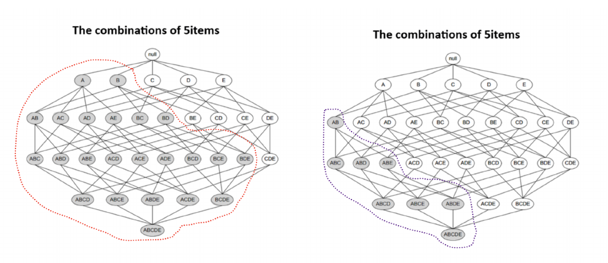

[output not shown]

| rule | lhs | rhs | support | confidence | coverage | lift | count |
| --- | --- | --- | --- | --- | --- | --- | --- |
| 1 | {REGENCY TEA PLATE PINK} | {REGENCY TEA PLATE GREEN} | 0.0054 | 0.90 | 0.0061 | 117.89 | 218 |
| 2 | {PACK OF 20 SKULL PAPER NAPKINS, PACK OF 6 SKULL PAPER CUPS} | {PACK OF 6 SKULL PAPER PLATES} | 0.0052 | 0.90 | 0.0058 | 100.02 | 209 |
| 3 | {CHILDS GARDEN FORK BLUE} | {CHILDS GARDEN TROWEL BLUE} | 0.0060 | 0.80 | 0.0074 | 99.52 | 239 |
| 4 | {REGENCY TEA PLATE PINK} | {REGENCY TEA PLATE ROSES} | 0.0053 | 0.88 | 0.0061 | 97.86 | 213 |
| 5 | {PACK OF 20 SKULL PAPER NAPKINS, PACK OF 6 SKULL PAPER PLATES} | {PACK OF 6 SKULL PAPER CUPS} | 0.0052 | 0.81 | 0.0064 | 96.72 | 209 |
| 6 | {REGENCY TEA PLATE GREEN} | {REGENCY TEA PLATE ROSES} | 0.0063 | 0.83 | 0.0076 | 92.97 | 254 |
| 7 | {SET/10 BLUE SPOTTY PARTY CANDLES} | {SET/10 PINK SPOTTY PARTY CANDLES} | 0.0058 | 0.80 | 0.0073 | 92.03 | 234 |
| 8 | {PACK OF 6 SKULL PAPER CUPS} | {PACK OF 6 SKULL PAPER PLATES} | 0.0068 | 0.81 | 0.0084 | 90.27 | 274 |
| 9 | {MONSTERS STENCIL CRAFT} | {HAPPY STENCIL CRAFT} | 0.0064 | 0.80 | 0.0080 | 72.21 | 256 |
| 10 | {FELTCRAFT PRINCESS CHARLOTTE DOLL, FELTCRAFT PRINCESS OLIVIA DOLL} | {FELTCRAFT PRINCESS LOLA DOLL} | 0.0050 | 0.84 | 0.0060 | 63.15 | 202 |
| 11 | {KEY FOB FRONT DOOR, KEY FOB SHED} | {KEY FOB BACK DOOR} | 0.0062 | 0.90 | 0.0069 | 61.57 | 249 |
| 12 | {WOODEN HEART CHRISTMAS SCANDINAVIAN, WOODEN TREE CHRISTMAS SCANDINAVIAN} | {WOODEN STAR CHRISTMAS SCANDINAVIAN} | 0.0062 | 0.88 | 0.0071 | 59.37 | 249 |
| 13 | {FELTCRAFT PRINCESS LOLA DOLL, FELTCRAFT PRINCESS OLIVIA DOLL} | {FELTCRAFT PRINCESS CHARLOTTE DOLL} | 0.0050 | 0.81 | 0.0062 | 58.14 | 202 |
| 14 | {BLUE SPOT CERAMIC DRAWER KNOB, BLUE STRIPE CERAMIC DRAWER KNOB, RED STRIPE CERAMIC DRAWER KNOB} | {RED SPOT CERAMIC DRAWER KNOB} | 0.0059 | 0.83 | 0.0070 | 52.10 | 235 |
| 15 | {RED SPOT CERAMIC DRAWER KNOB, WHITE SPOT BLUE CERAMIC DRAWER KNOB} | {BLUE SPOT CERAMIC DRAWER KNOB} | 0.0058 | 0.84 | 0.0069 | 51.38 | 234 |
| 16 | {BLUE STRIPE CERAMIC DRAWER KNOB, WHITE SPOT BLUE CERAMIC DRAWER KNOB, WHITE SPOT RED CERAMIC DRAWER KNOB} | {RED STRIPE CERAMIC DRAWER KNOB} | 0.0051 | 0.91 | 0.0056 | 51.14 | 204 |
| 17 | {BLUE STRIPE CERAMIC DRAWER KNOB, RED SPOT CERAMIC DRAWER KNOB, WHITE SPOT RED CERAMIC DRAWER KNOB} | {RED STRIPE CERAMIC DRAWER KNOB} | 0.0052 | 0.91 | 0.0057 | 50.75 | 207 |
| 18 | {BLUE SPOT CERAMIC DRAWER KNOB, BLUE STRIPE CERAMIC DRAWER KNOB, RED SPOT CERAMIC DRAWER KNOB} | {RED STRIPE CERAMIC DRAWER KNOB} | 0.0059 | 0.91 | 0.0065 | 50.72 | 235 |
| 19 | {KEY FOB BACK DOOR, KEY FOB GARAGE DESIGN} | {KEY FOB SHED} | 0.0059 | 0.86 | 0.0068 | 50.11 | 235 |
| 20 | {BLUE SPOT CERAMIC DRAWER KNOB, RED SPOT CERAMIC DRAWER KNOB, RED STRIPE CERAMIC DRAWER KNOB} | {BLUE STRIPE CERAMIC DRAWER KNOB} | 0.0059 | 0.86 | 0.0068 | 49.36 | 235 |

## Insights

[interactive chart not shown]

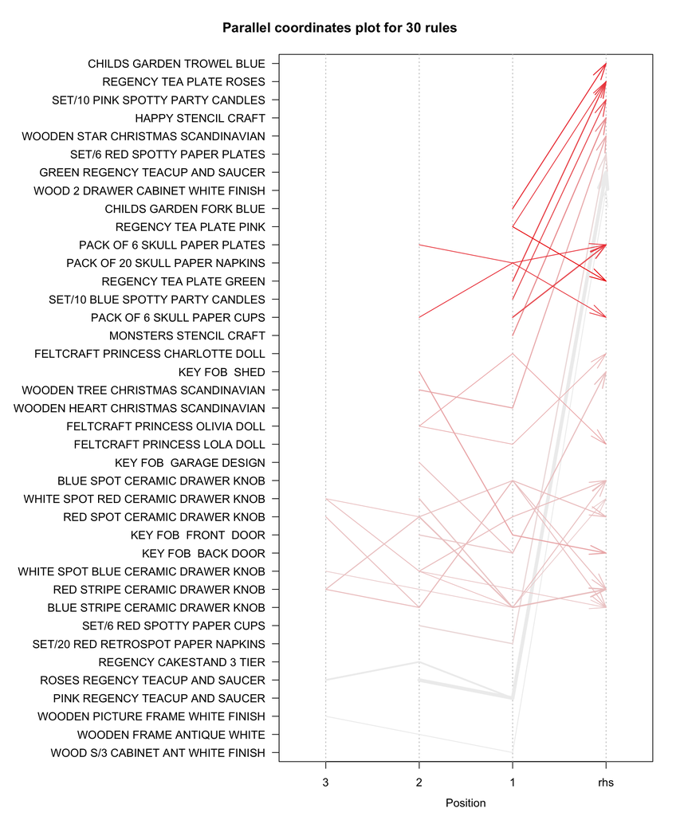

### Place

Although several of the ‘place’ decisions are made by manufacturers, there are a handful of decisions retailers can make to encourage customers to purchase more. Since our dataset belongs to an e-commerce retailer, we’ll focus on solutions geared towards both brick-and-mortar and virtual stores. The most obvious ‘place’ decision that retailers can make is product placement. Placing items with high lift values close to one another can be advantageous. For example, placing the different coloured items of the Regency Tea Plate set will make them more visible for customers looking to purchase a tea set. In e-commerce this will be the equivalent of placing products on the same row of a website.

### Promotion

There are two types of promotions that retailers typically communicate, one is about themselves and the other is about their products. Association analysis helps address the latter by showing us the most frequently bought products. Powered with this knowledge, retailers and e-retailers alike can produce their marketing collaterals featuring these products. Some examples would include featuring the Skull themed items–paper plates, paper plates and paper cups–together in a monthly or bi-weekly catalogue. For e-retailers, this will probably be in the form of an electronic brochure that customers scroll across on the website’s landing page.

Another approach that e-retailers can use, albeit only in the short-term, is to leverage retargeing. Since Google and Apple are implementing stricter privacy controls for the end user, retargeting won’t be a viable long-term solution. Nevertheless, e-retailers can further leverage this information by opting to retarget their customers once they leave the website. Organisations can provide accurate and timley retargeted ads to customers who are likely interested in the products of the targeted ads. This will ensure that potential customers will have top-of-mind awareness of your product and brand.

### Price

This is an area that association analysis alone cannot tackle but definitely provides a starting point and a direction for analysts to pursue. Pricing analytics in its own right can and should be involved in pricing decision making, however association analysis is useful for retailers as they’ll be empowered to think about offers and discounts on popular products. Retailers and e-retailers can use the information of products with high lift values to guide which produce categories or subcategories to discount.